# Plastics_May2018_DADA2

Winston Liu

February 07, 2020

# DESCRIPTION OF DATA (from Josh):

This data set is a duplicated time series of the microbiomes on 7 different kinds of recycle plastics that were simultaneously exposed for 70 days to running sea watet and then sampled on day 8, 16, 24, 32 and 70. The idea is to use the microbiomes as a tool to figure out the nature of the additives in plastics by comparing them to microbiomes growing on toxic coatings and other coatings in marine environments. The initial question is: How do the communities change with time and can we tell the plastics apart?

## Data storage

Downloaded from dds into /sharedspace/oysters/plastics Based on the Order_4860_Notes.rtf, it seems that “1st MiSeq run did not perform to specifications so they ran it a 2nd time and gave us both sets of data.” So will proceed with the data from Order 4860?

#Libraries

```r
library(readr)
library(fs)
library(R.utils)
library(tidyverse)
library(stringr)
library(phyloseq)
library(ggplot2)
library(dada2)
library(magrittr)
```

# INPUTS

Folder names:

```r
baseFolder2 <- "/sharedspace/oysters/plastics/rittschof/Order4860/Dressman_4860_18052402"
baseFolder1 <- "/sharedspace/oysters/plastics/rittschof/Order4860/Dressman_4860_180521"

outputFiltered <- "/sharedspace/oysters/plastics/scratch/filtered_May2018"
output.dir <- "/sharedspace/oysters/plastics/output"
ps.file <- file.path(output.dir,"ps_plastics_May2018.rds")
track.file <- file.path(output.dir,"track_plastics_May2018.rds")
```

Read in the files:

```r
run2.files <- list.files(baseFolder2, pattern = "R1_001.fastq.gz")
```

# SAMPLE TABLE

```r
dayNum <- as.numeric(str_extract(run2.files, "[0-9]+"))
plasticType <- (str_extract(run2.files, "[aA-zZ]+"))
sampleName <- paste(plasticType,dayNum, sep = "-")
R1.fileName <- run2.files
R2.fileName <- str_replace(run2.files,"R1","R2")
sampleInfo <- data.frame(sampleName, plasticType,dayNum,R1.fileName, R2.fileName)
sampleInfo %>% arrange(plasticType,dayNum)
```

[output not shown]

# View quality profiles

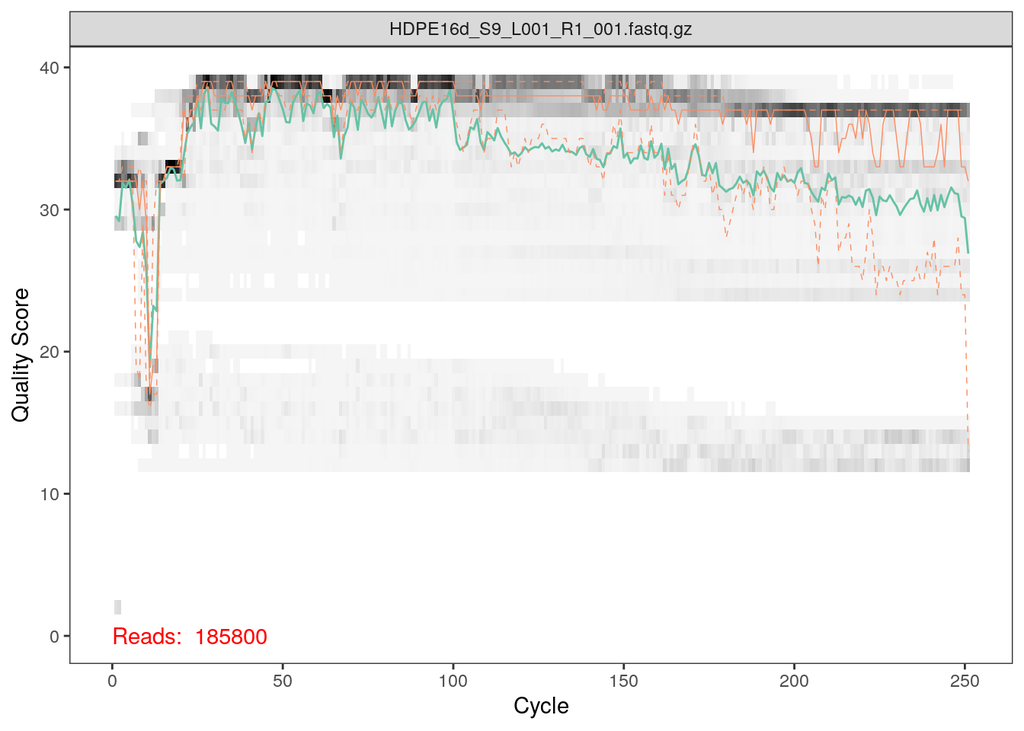

```r
i<-1
plotQualityProfile(file.path(baseFolder2, sampleInfo$R1.fileName[i]))
```

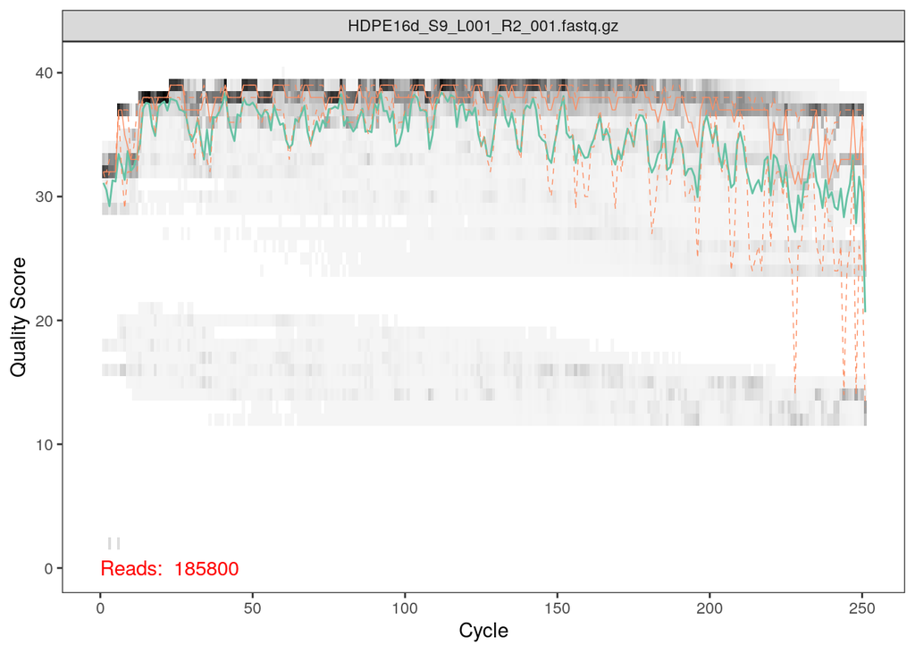

```r
plotQualityProfile(file.path(baseFolder2, sampleInfo$R2.fileName[i]))
```

# Perform filtering and trimming

### Generate filenames for the filtered fastq.gz files.

You need to use the names of the raw (demultiplexed) FASTQ files to generate a vector of names for the filtered FASTQs. You need separate vectors for the forward and reverse reads. It is a very good idea to put all the filtered FASTQs in their own directory.

```r
filtFs <- file.path(outputFiltered , paste0(sampleInfo$sampleName, "_F_filt.fastq.gz"))
filtRs <- file.path(outputFiltered , paste0(sampleInfo$sampleName, "_R_filt.fastq.gz"))
fnFs <- file.path(baseFolder2,as.character(sampleInfo$R1.fileName))
fnRs <- file.path(baseFolder2,as.character(sampleInfo$R2.fileName))
```

### Filter the forward and reverse reads

Now let’s do the filtering using the parameters we chose based on the quality plots

```r
filt.out <- filterAndTrim(fwd = fnFs, filt = filtFs, rev = fnRs, filt.rev = filtRs, trimLeft=10, truncLen=c(245,225),
              maxN=0, maxEE=c(2,2), truncQ=2, rm.phix=TRUE,
              compress=TRUE, multithread=FALSE) # On Windows set multithread=FALSE
```

```
## Creating output directory: /sharedspace/oysters/plastics/scratch/filtered_May2018
```

```r
filt.out
```

```
##                                  reads.in reads.out
## HDPE16d_S9_L001_R1_001.fastq.gz    185800    144637
## HDPE24d_S16_L001_R1_001.fastq.gz   154655     90457
## HDPE32d_S23_L001_R1_001.fastq.gz   280749    210598
## HDPE70d_S30_L001_R1_001.fastq.gz   238593    172316
## HDPE8d_S2_L001_R1_001.fastq.gz     261573    201974
## LDPE16d_S11_L001_R1_001.fastq.gz   204004    164030
## LDPE24d_S18_L001_R1_001.fastq.gz   178996    140049
## LDPE32d_S25_L001_R1_001.fastq.gz   219831    170917
## LDPE70d_S32_L001_R1_001.fastq.gz   218843    156398
## LDPE8d_S4_L001_R1_001.fastq.gz     373658    294259
## PC16d_S14_L001_R1_001.fastq.gz     252827    195170
## PC24d_S21_L001_R1_001.fastq.gz     301403    237040
## PC32d_S28_L001_R1_001.fastq.gz     289803    226214
## PC70d_S35_L001_R1_001.fastq.gz     327838    250038
## PC8d_S7_L001_R1_001.fastq.gz       476325    373832
## PET16d_S8_L001_R1_001.fastq.gz     373487    287231
## PET24d_S15_L001_R1_001.fastq.gz    224552    169772
## PET32d_S22_L001_R1_001.fastq.gz    271236    201490
## PET70d_S29_L001_R1_001.fastq.gz    308189    236305
## PET8d_S1_L001_R1_001.fastq.gz      368343    279945
## PP16d_S12_L001_R1_001.fastq.gz     327909    260561
## PP24d_S19_L001_R1_001.fastq.gz     245200    195624
## PP32d_S26_L001_R1_001.fastq.gz     315125    242692
## PP70d_S33_L001_R1_001.fastq.gz     489070    361328
## PP8d_S5_L001_R1_001.fastq.gz       370727    292015
## PS16d_S13_L001_R1_001.fastq.gz    1334274   1065988
## PS24d_S20_L001_R1_001.fastq.gz     295403    229024
## PS32d_S27_L001_R1_001.fastq.gz     300562    237845
## PS70d_S34_L001_R1_001.fastq.gz     271109    202109
## PS8d_S6_L001_R1_001.fastq.gz       284043    212755
## PVC16d_S10_L001_R1_001.fastq.gz    147228    113185
## PVC24d_S17_L001_R1_001.fastq.gz    247062    192260
## PVC32d_S24_L001_R1_001.fastq.gz    258318    197449
## PVC70d_S31_L001_R1_001.fastq.gz    229801    179228
## PVC8d_S3_L001_R1_001.fastq.gz      343351    272009
```

### Tweak Filtered FASTQ list

```r
filtFs <- filtFs[file_exists(filtFs)]
filtRs <- filtRs[file_exists(filtRs)]
sample.names <- filtFs  %>%
  basename %>%
  str_replace("_F_filt.fastq.gz","")
```

## Learn the Error Rates

With that bit of cleanup done, we are ready to build an error model from the filtered FASTQs. We do this seperately for the R1 and R2 FASTQs, since they have different patterns of errors, as we have seen.

```r
errF <- learnErrors(filtFs, multithread=TRUE)
```

```
## 104737620 total bases in 445692 reads from 3 samples will be used for learning the error rates.
```

```r
errR <- learnErrors(filtRs, multithread=TRUE)
```

```
## 132871720 total bases in 618008 reads from 4 samples will be used for learning the error rates.
```

It is always worthwhile, as a sanity check if nothing else, to visualize the estimated error rates:

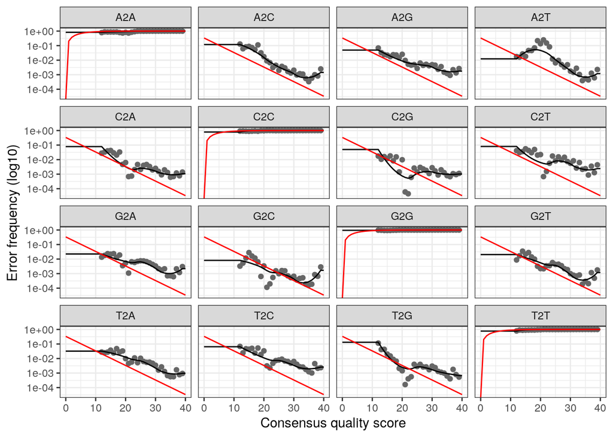

```r
plotErrors(errF, nominalQ=TRUE)
```

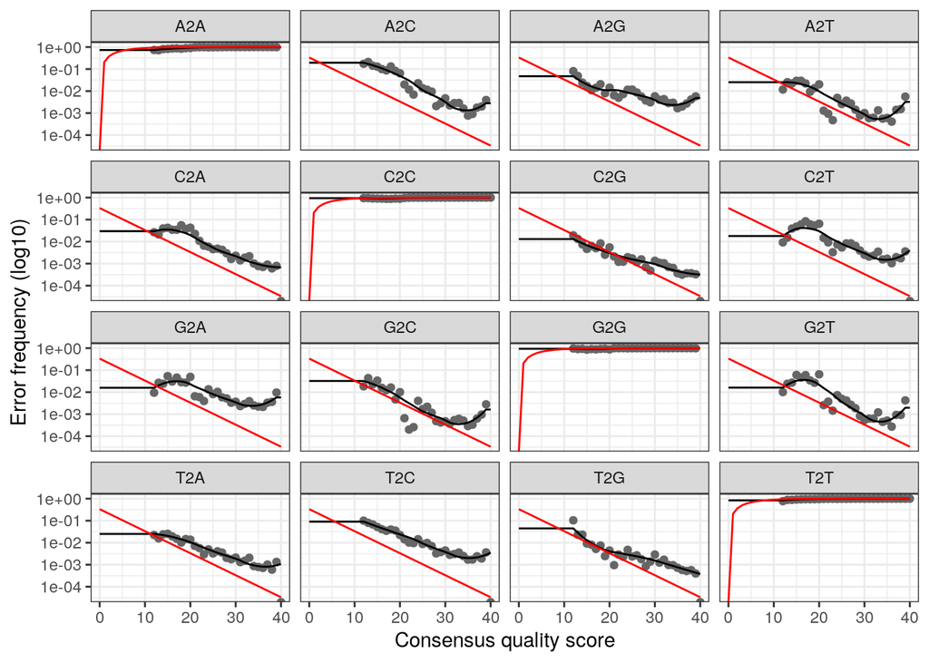

```r
plotErrors(errR, nominalQ=TRUE)
```

The error rates for each possible transition (eg. A->C, A->G, …) are shown. Points are the observed error rates for each consensus quality score. The black line shows the estimated error rates after convergence. The red line shows the error rates expected under the nominal definition of the Q-value. Here the black line (the estimated rates) fits the observed rates well, and the error rates drop with increased quality as expected.

Since we are using a small subset of the data, the learned error rates might look funny. This is OK for now, since we are just doing a pilot analysis.

## Dereplication

Dereplication combines all identical sequencing reads into “unique sequences” with a corresponding “abundance” tally: the number of reads with that unique sequence. Dereplication substantially reduces computation time for the inference step, since we only need to do inference for unique sequences.

```r
derepFs <- derepFastq(filtFs, verbose=TRUE)
```

```
## Dereplicating sequence entries in Fastq file: /sharedspace/oysters/plastics/scratch/filtered_May2018/HDPE-16_F_filt.fastq.gz
```

```
## Encountered 36757 unique sequences from 144637 total sequences read.
```

```
## Dereplicating sequence entries in Fastq file: /sharedspace/oysters/plastics/scratch/filtered_May2018/HDPE-24_F_filt.fastq.gz
```

```
## Encountered 26429 unique sequences from 90457 total sequences read.
```

```
## Dereplicating sequence entries in Fastq file: /sharedspace/oysters/plastics/scratch/filtered_May2018/HDPE-32_F_filt.fastq.gz
```

```
## Encountered 67956 unique sequences from 210598 total sequences read.
```

```
## Dereplicating sequence entries in Fastq file: /sharedspace/oysters/plastics/scratch/filtered_May2018/HDPE-70_F_filt.fastq.gz
```

```
## Encountered 69332 unique sequences from 172316 total sequences read.
```

```
## Dereplicating sequence entries in Fastq file: /sharedspace/oysters/plastics/scratch/filtered_May2018/HDPE-8_F_filt.fastq.gz
```

```
## Encountered 57658 unique sequences from 201974 total sequences read.
```

```
## Dereplicating sequence entries in Fastq file: /sharedspace/oysters/plastics/scratch/filtered_May2018/LDPE-16_F_filt.fastq.gz
```

```
## Encountered 47021 unique sequences from 164030 total sequences read.
```

```
## Dereplicating sequence entries in Fastq file: /sharedspace/oysters/plastics/scratch/filtered_May2018/LDPE-24_F_filt.fastq.gz
```

```
## Encountered 37196 unique sequences from 140049 total sequences read.
```

```
## Dereplicating sequence entries in Fastq file: /sharedspace/oysters/plastics/scratch/filtered_May2018/LDPE-32_F_filt.fastq.gz
```

```
## Encountered 48309 unique sequences from 170917 total sequences read.
```

```
## Dereplicating sequence entries in Fastq file: /sharedspace/oysters/plastics/scratch/filtered_May2018/LDPE-70_F_filt.fastq.gz
```

```
## Encountered 60131 unique sequences from 156398 total sequences read.
```

```
## Dereplicating sequence entries in Fastq file: /sharedspace/oysters/plastics/scratch/filtered_May2018/LDPE-8_F_filt.fastq.gz
```

```
## Encountered 70404 unique sequences from 294259 total sequences read.
```

```
## Dereplicating sequence entries in Fastq file: /sharedspace/oysters/plastics/scratch/filtered_May2018/PC-16_F_filt.fastq.gz
```

```
## Encountered 59055 unique sequences from 195170 total sequences read.
```

```
## Dereplicating sequence entries in Fastq file: /sharedspace/oysters/plastics/scratch/filtered_May2018/PC-24_F_filt.fastq.gz
```

```
## Encountered 70356 unique sequences from 237040 total sequences read.
```

```
## Dereplicating sequence entries in Fastq file: /sharedspace/oysters/plastics/scratch/filtered_May2018/PC-32_F_filt.fastq.gz
```

```
## Encountered 72282 unique sequences from 226214 total sequences read.
```

```
## Dereplicating sequence entries in Fastq file: /sharedspace/oysters/plastics/scratch/filtered_May2018/PC-70_F_filt.fastq.gz
```

```
## Encountered 91214 unique sequences from 250038 total sequences read.
```

```
## Dereplicating sequence entries in Fastq file: /sharedspace/oysters/plastics/scratch/filtered_May2018/PC-8_F_filt.fastq.gz
```

```
## Encountered 87989 unique sequences from 373832 total sequences read.
```

```
## Dereplicating sequence entries in Fastq file: /sharedspace/oysters/plastics/scratch/filtered_May2018/PET-16_F_filt.fastq.gz
```

```
## Encountered 85725 unique sequences from 287231 total sequences read.
```

```
## Dereplicating sequence entries in Fastq file: /sharedspace/oysters/plastics/scratch/filtered_May2018/PET-24_F_filt.fastq.gz
```

```
## Encountered 50975 unique sequences from 169772 total sequences read.
```

```
## Dereplicating sequence entries in Fastq file: /sharedspace/oysters/plastics/scratch/filtered_May2018/PET-32_F_filt.fastq.gz
```

```
## Encountered 76333 unique sequences from 201490 total sequences read.
```

```
## Dereplicating sequence entries in Fastq file: /sharedspace/oysters/plastics/scratch/filtered_May2018/PET-70_F_filt.fastq.gz
```

```
## Encountered 83490 unique sequences from 236305 total sequences read.
```

```
## Dereplicating sequence entries in Fastq file: /sharedspace/oysters/plastics/scratch/filtered_May2018/PET-8_F_filt.fastq.gz
```

```
## Encountered 91075 unique sequences from 279945 total sequences read.
```

```
## Dereplicating sequence entries in Fastq file: /sharedspace/oysters/plastics/scratch/filtered_May2018/PP-16_F_filt.fastq.gz
```

```
## Encountered 66425 unique sequences from 260561 total sequences read.
```

```
## Dereplicating sequence entries in Fastq file: /sharedspace/oysters/plastics/scratch/filtered_May2018/PP-24_F_filt.fastq.gz
```

```
## Encountered 53988 unique sequences from 195624 total sequences read.
```

```
## Dereplicating sequence entries in Fastq file: /sharedspace/oysters/plastics/scratch/filtered_May2018/PP-32_F_filt.fastq.gz
```

```
## Encountered 79633 unique sequences from 242692 total sequences read.
```

```
## Dereplicating sequence entries in Fastq file: /sharedspace/oysters/plastics/scratch/filtered_May2018/PP-70_F_filt.fastq.gz
```

```
## Encountered 126154 unique sequences from 361328 total sequences read.
```

```
## Dereplicating sequence entries in Fastq file: /sharedspace/oysters/plastics/scratch/filtered_May2018/PP-8_F_filt.fastq.gz
```

```
## Encountered 81892 unique sequences from 292015 total sequences read.
```

```
## Dereplicating sequence entries in Fastq file: /sharedspace/oysters/plastics/scratch/filtered_May2018/PS-16_F_filt.fastq.gz
```

```
## .Encountered 221129 unique sequences from 1065988 total sequences read.
## Dereplicating sequence entries in Fastq file: /sharedspace/oysters/plastics/scratch/filtered_May2018/PS-24_F_filt.fastq.gz
## Encountered 69579 unique sequences from 229024 total sequences read.
## Dereplicating sequence entries in Fastq file: /sharedspace/oysters/plastics/scratch/filtered_May2018/PS-32_F_filt.fastq.gz
## Encountered 75725 unique sequences from 237845 total sequences read.
## Dereplicating sequence entries in Fastq file: /sharedspace/oysters/plastics/scratch/filtered_May2018/PS-70_F_filt.fastq.gz
## Encountered 70856 unique sequences from 202109 total sequences read.
## Dereplicating sequence entries in Fastq file: /sharedspace/oysters/plastics/scratch/filtered_May2018/PS-8_F_filt.fastq.gz
## Encountered 57259 unique sequences from 212755 total sequences read.
## Dereplicating sequence entries in Fastq file: /sharedspace/oysters/plastics/scratch/filtered_May2018/PVC-16_F_filt.fastq.gz
## Encountered 28111 unique sequences from 113185 total sequences read.
## Dereplicating sequence entries in Fastq file: /sharedspace/oysters/plastics/scratch/filtered_May2018/PVC-24_F_filt.fastq.gz
## Encountered 44985 unique sequences from 192260 total sequences read.
## Dereplicating sequence entries in Fastq file: /sharedspace/oysters/plastics/scratch/filtered_May2018/PVC-32_F_filt.fastq.gz
## Encountered 50203 unique sequences from 197449 total sequences read.
## Dereplicating sequence entries in Fastq file: /sharedspace/oysters/plastics/scratch/filtered_May2018/PVC-70_F_filt.fastq.gz
## Encountered 42963 unique sequences from 179228 total sequences read.
## Dereplicating sequence entries in Fastq file: /sharedspace/oysters/plastics/scratch/filtered_May2018/PVC-8_F_filt.fastq.gz
## Encountered 71929 unique sequences from 272009 total sequences read.
```

```r
derepRs <- derepFastq(filtRs, verbose=TRUE)
```

```
## Dereplicating sequence entries in Fastq file: /sharedspace/oysters/plastics/scratch/filtered_May2018/HDPE-16_R_filt.fastq.gz
## Encountered 37522 unique sequences from 144637 total sequences read.
## Dereplicating sequence entries in Fastq file: /sharedspace/oysters/plastics/scratch/filtered_May2018/HDPE-24_R_filt.fastq.gz
## Encountered 44755 unique sequences from 90457 total sequences read.
## Dereplicating sequence entries in Fastq file: /sharedspace/oysters/plastics/scratch/filtered_May2018/HDPE-32_R_filt.fastq.gz
## Encountered 78710 unique sequences from 210598 total sequences read.
## Dereplicating sequence entries in Fastq file: /sharedspace/oysters/plastics/scratch/filtered_May2018/HDPE-70_R_filt.fastq.gz
## Encountered 59966 unique sequences from 172316 total sequences read.
## Dereplicating sequence entries in Fastq file: /sharedspace/oysters/plastics/scratch/filtered_May2018/HDPE-8_R_filt.fastq.gz
## Encountered 53941 unique sequences from 201974 total sequences read.
## Dereplicating sequence entries in Fastq file: /sharedspace/oysters/plastics/scratch/filtered_May2018/LDPE-16_R_filt.fastq.gz
## Encountered 47817 unique sequences from 164030 total sequences read.
## Dereplicating sequence entries in Fastq file: /sharedspace/oysters/plastics/scratch/filtered_May2018/LDPE-24_R_filt.fastq.gz
## Encountered 32731 unique sequences from 140049 total sequences read.
## Dereplicating sequence entries in Fastq file: /sharedspace/oysters/plastics/scratch/filtered_May2018/LDPE-32_R_filt.fastq.gz
## Encountered 44456 unique sequences from 170917 total sequences read.
## Dereplicating sequence entries in Fastq file: /sharedspace/oysters/plastics/scratch/filtered_May2018/LDPE-70_R_filt.fastq.gz
## Encountered 53199 unique sequences from 156398 total sequences read.
## Dereplicating sequence entries in Fastq file: /sharedspace/oysters/plastics/scratch/filtered_May2018/LDPE-8_R_filt.fastq.gz
## Encountered 69600 unique sequences from 294259 total sequences read.
## Dereplicating sequence entries in Fastq file: /sharedspace/oysters/plastics/scratch/filtered_May2018/PC-16_R_filt.fastq.gz
## Encountered 53772 unique sequences from 195170 total sequences read.
## Dereplicating sequence entries in Fastq file: /sharedspace/oysters/plastics/scratch/filtered_May2018/PC-24_R_filt.fastq.gz
## Encountered 89265 unique sequences from 237040 total sequences read.
## Dereplicating sequence entries in Fastq file: /sharedspace/oysters/plastics/scratch/filtered_May2018/PC-32_R_filt.fastq.gz
## Encountered 70104 unique sequences from 226214 total sequences read.
## Dereplicating sequence entries in Fastq file: /sharedspace/oysters/plastics/scratch/filtered_May2018/PC-70_R_filt.fastq.gz
## Encountered 97484 unique sequences from 250038 total sequences read.
## Dereplicating sequence entries in Fastq file: /sharedspace/oysters/plastics/scratch/filtered_May2018/PC-8_R_filt.fastq.gz
## Encountered 89271 unique sequences from 373832 total sequences read.
## Dereplicating sequence entries in Fastq file: /sharedspace/oysters/plastics/scratch/filtered_May2018/PET-16_R_filt.fastq.gz
## Encountered 85767 unique sequences from 287231 total sequences read.
## Dereplicating sequence entries in Fastq file: /sharedspace/oysters/plastics/scratch/filtered_May2018/PET-24_R_filt.fastq.gz
## Encountered 50349 unique sequences from 169772 total sequences read.
## Dereplicating sequence entries in Fastq file: /sharedspace/oysters/plastics/scratch/filtered_May2018/PET-32_R_filt.fastq.gz
## Encountered 71478 unique sequences from 201490 total sequences read.
## Dereplicating sequence entries in Fastq file: /sharedspace/oysters/plastics/scratch/filtered_May2018/PET-70_R_filt.fastq.gz
## Encountered 85507 unique sequences from 236305 total sequences read.
## Dereplicating sequence entries in Fastq file: /sharedspace/oysters/plastics/scratch/filtered_May2018/PET-8_R_filt.fastq.gz
## Encountered 90049 unique sequences from 279945 total sequences read.
```

[output cut: 15 more lines]

```
## Encountered 74185 unique sequences from 237845 total sequences read.
## Dereplicating sequence entries in Fastq file: /sharedspace/oysters/plastics/scratch/filtered_May2018/PS-70_R_filt.fastq.gz
## Encountered 68384 unique sequences from 202109 total sequences read.
## Dereplicating sequence entries in Fastq file: /sharedspace/oysters/plastics/scratch/filtered_May2018/PS-8_R_filt.fastq.gz
## Encountered 49681 unique sequences from 212755 total sequences read.
## Dereplicating sequence entries in Fastq file: /sharedspace/oysters/plastics/scratch/filtered_May2018/PVC-16_R_filt.fastq.gz
## Encountered 25001 unique sequences from 113185 total sequences read.
## Dereplicating sequence entries in Fastq file: /sharedspace/oysters/plastics/scratch/filtered_May2018/PVC-24_R_filt.fastq.gz
## Encountered 45598 unique sequences from 192260 total sequences read.
## Dereplicating sequence entries in Fastq file: /sharedspace/oysters/plastics/scratch/filtered_May2018/PVC-32_R_filt.fastq.gz
## Encountered 52251 unique sequences from 197449 total sequences read.
## Dereplicating sequence entries in Fastq file: /sharedspace/oysters/plastics/scratch/filtered_May2018/PVC-70_R_filt.fastq.gz
## Encountered 39987 unique sequences from 179228 total sequences read.
## Dereplicating sequence entries in Fastq file: /sharedspace/oysters/plastics/scratch/filtered_May2018/PVC-8_R_filt.fastq.gz
## Encountered 70603 unique sequences from 272009 total sequences read.
```

### Rename derep objects

`derepFastq` returns a list of derep objects that are named based on the input filename. For later steps it is going to be more convenient if each derep object is named with just it’s sample name, so let’s rename the derep objects using the sample name vector that we created earlier.

```r
names(derepFs) <- sampleInfo$sampleName
names(derepRs) <- sampleInfo$sampleName
```

## Sample Inference

Now you need to infer the true sequences from the dereplicated data.

```r
dadaFs <- dada(derepFs, err=errF, multithread=TRUE)
```

```
## Sample 1 - 144637 reads in 36757 unique sequences.
## Sample 2 - 90457 reads in 26429 unique sequences.
## Sample 3 - 210598 reads in 67956 unique sequences.
## Sample 4 - 172316 reads in 69332 unique sequences.
## Sample 5 - 201974 reads in 57658 unique sequences.
## Sample 6 - 164030 reads in 47021 unique sequences.
## Sample 7 - 140049 reads in 37196 unique sequences.
## Sample 8 - 170917 reads in 48309 unique sequences.
## Sample 9 - 156398 reads in 60131 unique sequences.
## Sample 10 - 294259 reads in 70404 unique sequences.
## Sample 11 - 195170 reads in 59055 unique sequences.
## Sample 12 - 237040 reads in 70356 unique sequences.
## Sample 13 - 226214 reads in 72282 unique sequences.
## Sample 14 - 250038 reads in 91214 unique sequences.
## Sample 15 - 373832 reads in 87989 unique sequences.
## Sample 16 - 287231 reads in 85725 unique sequences.
## Sample 17 - 169772 reads in 50975 unique sequences.
## Sample 18 - 201490 reads in 76333 unique sequences.
## Sample 19 - 236305 reads in 83490 unique sequences.
## Sample 20 - 279945 reads in 91075 unique sequences.
## Sample 21 - 260561 reads in 66425 unique sequences.
## Sample 22 - 195624 reads in 53988 unique sequences.
## Sample 23 - 242692 reads in 79633 unique sequences.
## Sample 24 - 361328 reads in 126154 unique sequences.
## Sample 25 - 292015 reads in 81892 unique sequences.
## Sample 26 - 1065988 reads in 221129 unique sequences.
## Sample 27 - 229024 reads in 69579 unique sequences.
## Sample 28 - 237845 reads in 75725 unique sequences.
## Sample 29 - 202109 reads in 70856 unique sequences.
## Sample 30 - 212755 reads in 57259 unique sequences.
## Sample 31 - 113185 reads in 28111 unique sequences.
## Sample 32 - 192260 reads in 44985 unique sequences.
## Sample 33 - 197449 reads in 50203 unique sequences.
## Sample 34 - 179228 reads in 42963 unique sequences.
## Sample 35 - 272009 reads in 71929 unique sequences.
```

```r
dadaRs <- dada(derepRs, err=errR, multithread=TRUE)
```

```
## Sample 1 - 144637 reads in 37522 unique sequences.
## Sample 2 - 90457 reads in 44755 unique sequences.
## Sample 3 - 210598 reads in 78710 unique sequences.
## Sample 4 - 172316 reads in 59966 unique sequences.
## Sample 5 - 201974 reads in 53941 unique sequences.
## Sample 6 - 164030 reads in 47817 unique sequences.
## Sample 7 - 140049 reads in 32731 unique sequences.
## Sample 8 - 170917 reads in 44456 unique sequences.
## Sample 9 - 156398 reads in 53199 unique sequences.
## Sample 10 - 294259 reads in 69600 unique sequences.
## Sample 11 - 195170 reads in 53772 unique sequences.
## Sample 12 - 237040 reads in 89265 unique sequences.
## Sample 13 - 226214 reads in 70104 unique sequences.
## Sample 14 - 250038 reads in 97484 unique sequences.
## Sample 15 - 373832 reads in 89271 unique sequences.
## Sample 16 - 287231 reads in 85767 unique sequences.
## Sample 17 - 169772 reads in 50349 unique sequences.
## Sample 18 - 201490 reads in 71478 unique sequences.
## Sample 19 - 236305 reads in 85507 unique sequences.
## Sample 20 - 279945 reads in 90049 unique sequences.
## Sample 21 - 260561 reads in 68218 unique sequences.
## Sample 22 - 195624 reads in 61215 unique sequences.
## Sample 23 - 242692 reads in 68931 unique sequences.
## Sample 24 - 361328 reads in 124084 unique sequences.
## Sample 25 - 292015 reads in 82343 unique sequences.
## Sample 26 - 1065988 reads in 255496 unique sequences.
## Sample 27 - 229024 reads in 67026 unique sequences.
## Sample 28 - 237845 reads in 74185 unique sequences.
## Sample 29 - 202109 reads in 68384 unique sequences.
## Sample 30 - 212755 reads in 49681 unique sequences.
## Sample 31 - 113185 reads in 25001 unique sequences.
## Sample 32 - 192260 reads in 45598 unique sequences.
## Sample 33 - 197449 reads in 52251 unique sequences.
## Sample 34 - 179228 reads in 39987 unique sequences.
## Sample 35 - 272009 reads in 70603 unique sequences.
```

## Merge paired reads

Each pair of R1 and R2 reads represents one observed sequence, so we ultimately need to combine them into a single sequence. The paired reads allows us to reduce sequence error where the reads overlap because that part of the insert has been sequenced twice so we can compare the two sequences and be sure they agree. This is why it is desireable to have reads that overlap as much as possible.

```r
mergers <- mergePairs(dadaFs, derepFs, dadaRs, derepRs, verbose=TRUE)
```

```
## 76745 paired-reads (in 919 unique pairings) successfully merged out of 141014 (in 6994 pairings) input.
```

```
## 52900 paired-reads (in 403 unique pairings) successfully merged out of 86779 (in 4151 pairings) input.
```

```
## 85269 paired-reads (in 1347 unique pairings) successfully merged out of 198131 (in 16584 pairings) input.
```

```
## 58447 paired-reads (in 1691 unique pairings) successfully merged out of 157198 (in 18145 pairings) input.
```

```
## 51157 paired-reads (in 878 unique pairings) successfully merged out of 196032 (in 13630 pairings) input.
```

```
## 75239 paired-reads (in 1120 unique pairings) successfully merged out of 157491 (in 11550 pairings) input.
```

```
## 67830 paired-reads (in 862 unique pairings) successfully merged out of 135345 (in 7770 pairings) input.
```

```
## 70343 paired-reads (in 1036 unique pairings) successfully merged out of 161959 (in 11099 pairings) input.
```

```
## 34941 paired-reads (in 1130 unique pairings) successfully merged out of 144962 (in 15489 pairings) input.
```

```
## 58997 paired-reads (in 1031 unique pairings) successfully merged out of 287712 (in 17198 pairings) input.
```

```
## 87051 paired-reads (in 1589 unique pairings) successfully merged out of 186319 (in 14380 pairings) input.
```

```
## 111762 paired-reads (in 1994 unique pairings) successfully merged out of 224182 (in 17693 pairings) input.
```

```
## 98751 paired-reads (in 2063 unique pairings) successfully merged out of 212272 (in 18203 pairings) input.
```

```
## 95186 paired-reads (in 2456 unique pairings) successfully merged out of 229537 (in 22776 pairings) input.
```

```
## 100747 paired-reads (in 1705 unique pairings) successfully merged out of 366704 (in 18402 pairings) input.
```

```
## 136759 paired-reads (in 2008 unique pairings) successfully merged out of 273537 (in 22650 pairings) input.
```

```
## 81706 paired-reads (in 1088 unique pairings) successfully merged out of 161772 (in 11717 pairings) input.
```

```
## 70979 paired-reads (in 1638 unique pairings) successfully merged out of 185316 (in 20794 pairings) input.
```

```
## 85489 paired-reads (in 2292 unique pairings) successfully merged out of 217052 (in 22038 pairings) input.
```

```
## 68638 paired-reads (in 1786 unique pairings) successfully merged out of 264899 (in 26479 pairings) input.
```

```
## 138347 paired-reads (in 2017 unique pairings) successfully merged out of 251372 (in 15207 pairings) input.
```

```
## 107883 paired-reads (in 1777 unique pairings) successfully merged out of 186510 (in 12881 pairings) input.
```

```
## 105180 paired-reads (in 2069 unique pairings) successfully merged out of 227904 (in 21151 pairings) input.
```

```
## 132606 paired-reads (in 2942 unique pairings) successfully merged out of 336828 (in 35242 pairings) input.
```

```
## 94814 paired-reads (in 1916 unique pairings) successfully merged out of 282679 (in 22241 pairings) input.
```

```
## 468833 paired-reads (in 5333 unique pairings) successfully merged out of 1042076 (in 48156 pairings) input.
```

```
## 86305 paired-reads (in 1608 unique pairings) successfully merged out of 218399 (in 16717 pairings) input.
```

```
## 85186 paired-reads (in 1606 unique pairings) successfully merged out of 223368 (in 19434 pairings) input.
```

```
## 76786 paired-reads (in 1976 unique pairings) successfully merged out of 187652 (in 18397 pairings) input.
```

```
## 36972 paired-reads (in 570 unique pairings) successfully merged out of 208061 (in 10640 pairings) input.
```

```
## 56572 paired-reads (in 840 unique pairings) successfully merged out of 109901 (in 5122 pairings) input.
```

```
## 75936 paired-reads (in 1295 unique pairings) successfully merged out of 187166 (in 8983 pairings) input.
```

```
## 59930 paired-reads (in 1307 unique pairings) successfully merged out of 189407 (in 11570 pairings) input.
```

```
## 37174 paired-reads (in 748 unique pairings) successfully merged out of 173074 (in 8963 pairings) input.
```

```
## 113565 paired-reads (in 1767 unique pairings) successfully merged out of 263265 (in 15726 pairings) input.
```

The results of `mergePairs` is a list of data frames with one data frame for each sample. Each data frame contains the unique merged sequences observed for that sample along with information about each sequence.

Paired reads that did not perfectly match in the overlapping region were removed by `mergePairs`.

## Construct sequence table

We can now construct a sequence table of our samples. This the equivalent of the OTU table produced by other methods. The sequence table has a row for each sample and a column for each ASV (the DADA2 equivalent of an OTU), with the count of the number of each ASV observed in each sample.

```r
seqtab <- makeSequenceTable(mergers)
```

```r
dim(seqtab)
```

```
## [1]    35 32175
```

Let’s check the size distribution of the ASVs we have inferred.

```r
table(nchar(getSequences(seqtab)))
```

```
##
##   235   236   237   238   239   240   241   242   243   244   245   246   248   249   250   252   253   254   255   256   257   258   259
##    14     1     1     1     5     2     2    36     1     1     1     4     3     2     1     7     1    38     3     1     1     1     1
##   261   262   263   264   266   267   268   269   270   273   274   275   276   277   278   279   280   281   282   283   284   286   287
##     4     1     1     2     3     3     4     1     3     1     2     4     1     4    28     3     1     1     3     1     6     3     1
##   289   290   294   295   296   297   299   300   303   306   309   310   312   313   314   315   316   317   318   319   321   322   327
##     1     1     5     1     3     1     5     2     5     1     1     1     1     1     1     3     3     1     4     2     3     7     1
##   328   331   332   333   335   337   338   339   340   341   342   343   344   345   346   347   348   349   351   352   353   355   356
##     1     1     2    90     3     1     2     1     1     1     1     4     2     1     4     3     2     1     1     4    12     3     1
##   357   358   359   360   362   364   365   366   368   369   371   372   374   376   377   378   379   380   383   385   386   387   388
##     9    10     4     2     8     3     1     6     4     1     3     1     4     4     1     1     2     2     6     5     2     1     1
##   389   390   391   392   394   396   397   398   399   400   401   402   403   404   405   406   407   408   410   411   412   413   414
##     5     6    15     2     2     4     1     8     5     3    14    23    52    15    20     3     2     9     5     4     4     2     5
##   415   416   417   418   419   420   421   422   423   424   425   426   427   428   429   430   431   432   433   434   435   436   437
##     7    10    19    64   350 23526  2908  1118  1259   710   129    91    83    71    45    44    47    24    24    50   184    36    79
##   438
##   602
```

## Remove chimeras

The core `dada` method removes substitution and indel errors, but chimeras remain. Fortunately, the accuracy of the sequences after denoising makes identifying chimeras simpler than it is when dealing with fuzzy OTUs: all sequences which can be exactly reconstructed as a bimera (two-parent chimera) from more abundant sequences. Let’s remove chimeric sequences

```r
seqtab.nochim <- removeBimeraDenovo(seqtab, method="consensus", multithread=TRUE, verbose=TRUE)
```

```
## Identified 19262 bimeras out of 32175 input sequences.
```

## Track reads through the pipeline

As a final check let’s make a table showing how many reads remain after each step in the pipeline for each sample.

```r
getN <- function(x) sum(getUniques(x))
track <- filt.out %>%
  as.data.frame %>%
  rownames_to_column %>%
  mutate(rowname=str_replace(rowname, "_R1.fastq.gz","")) %>%
  rename(sample=rowname, input=reads.in, filtered=reads.out)

dadaFs %>%
  sapply(getN) %>%
  as_tibble(rownames = NA) %>%
  rownames_to_column %>%
  rename(sample=rowname, denoised=value) ->
  denoised

track %<>% full_join(denoised, by=c("sample"))

mergers %>%
  sapply(getN) %>%
  data.frame %>%
  rownames_to_column %>%
  rename(sample=rowname, merged='.') ->
  merged

track %<>% full_join(merged, by=c("sample"))


seqtab %>%
  rowSums %>%
  data.frame %>%
  rownames_to_column() %>%
  rename(sample=rowname, tabled = '.') ->
  tabled
#   denoised

track %<>% full_join(tabled, by=c("sample"))

seqtab.nochim %>%
  rowSums %>%
  data.frame %>%
  rownames_to_column() %>%
  rename(sample=rowname, nochim='.') ->
  nochim

track %<>% full_join(nochim, by=c("sample"))

track %>%
  arrange(as.numeric(sample))
write_rds(track, track.file)
```

[output not shown]

This is a great place to do a last **sanity check**. Outside of filtering (depending on how stringent you want to be) there should no step in which a majority of reads are lost. If a majority of reads failed to merge, you may need to revisit the `truncLen` parameter used in the filtering step and make sure that the truncated reads span your amplicon. If a majority of reads failed to pass the chimera check, you may need to revisit the removal of primers, as the ambiguous nucleotides in unremoved primers interfere with chimera identification.

## Assign taxonomy

Now you can assign taxonomy! You should use this taxonomy reference files : `/data/references/dada/silva_nr_v132_train_set.fa.gz`

```r
silva.ref <- '/data/references/dada/silva_nr_v132_train_set.fa.gz'
taxa <- assignTaxonomy(seqtab.nochim, silva.ref, multithread=TRUE)
```

# Phyloseq

We are now done we the DADA2 pipeline. Let’s put the results into a phyloseq object and save it to an RDS for safe keeping!

## Make a Phyloseq Object

Now we can construct a phyloseq object directly from the dada2 outputs and the map data frame.

```r
otus = otu_table(seqtab.nochim, taxa_are_rows=FALSE)

sampleInfo %>%
  select(sampleName,plasticType,dayNum) %>%
  column_to_rownames(var = "sampleName") ->
  sd

ps <- phyloseq(otus,
               sd,
               tax_table(taxa))
```

And `print` your phyloseq object to be sure it was created correctly

```r
print(ps)
```

```
## phyloseq-class experiment-level object
## otu_table()   OTU Table:         [ 12913 taxa and 35 samples ]
## tax_table()   Taxonomy Table:    [ 12913 taxa by 6 taxonomic ranks ]
```

Your results from the previous chunk should look like this (number of taxa could be different depending on parameter choices):

```
phyloseq-class experiment-level object
otu_table()   OTU Table:         [ 234 taxa and 107 samples ]
sample_data() Sample Data:       [ 107 samples by 17 sample variables ]
tax_table()   Taxonomy Table:    [ 234 taxa by 6 taxonomic ranks ]
```

## Save Phyloseq to RDS

Any R object can be saved to an RDS file. It is a good idea to do this for any object that is time consuming to generate and is reasonably small in size. Even when the object was generated reproducibly, it can be frustrating to wait minutes or hours to regenerate when you are ready to perform downstream analyses.

We will do this for our phyloseq object to a file since it is quite small (especially compared to the size of the input FASTQ files), and there were several time consuming computational steps required to generate it.

```r
write_rds(ps, ps.file)
```

## Check Phyloseq RDS

We can now confirm that it worked. Load your phyloseq RDS and `print` it. The results should be the same as above.

```r
print(read_rds(ps.file))
```

```
## phyloseq-class experiment-level object
## otu_table()   OTU Table:         [ 12913 taxa and 35 samples ]
## tax_table()   Taxonomy Table:    [ 12913 taxa by 6 taxonomic ranks ]
```